# Data Visualization of Prosper Loan Data

## The Question:

## Through four examples, can we explain the variation between Interest Rate and APR using a third variable?

What do we know at the start of this project? Most of have taken out a loan at some point. So most of us know that in the loan funding process, a customer's interest rate is established prior to an APR.

The interest rate (often called Rate) mostly consists of market conditions around the prime interest rate as well as a customer's creditworthiness.

We also know that APR is determined by the bank adding fees (loan orgination, assessment, document fees, etc.,) to the cost of the loan. These fees are added up and converted into percentages points. The percentage points are added onto the (previously determined) interest rate and the sum of those becomes the APR.

If, the fees that determine the APR are constant, meaning they are applied uniformly throughout the range of interest rates, then the relationship of Interest Rate to APR should be quite linear (uniform), with very little variation.

That's what we'll be exploring here. How close to linear is the relationship between Interest Rate to APR?

And, if variation is present, can an additioanal third variable be introduced (like debt to income ration, credit score, loan term and loan orgination date) to see if that explains some of that variation?

## Let's create a "Perfect World" example of Interest Rate to APR.

We can illustrate the linear relationship between interest rate & APR by creating a perfect enviroment showcasing just that.

We'll create an Interest Rate column ("Rate") and a NoFees column (where an APR equals the Interest Rate) and a WithFees column (where any point on the Interest Rate would add an additional 0.005 respresenting lender fees to arrive at an APR).

Illustrating that table graphically, our "perfect world" example of Interest Rate & APR graphically looks like this:

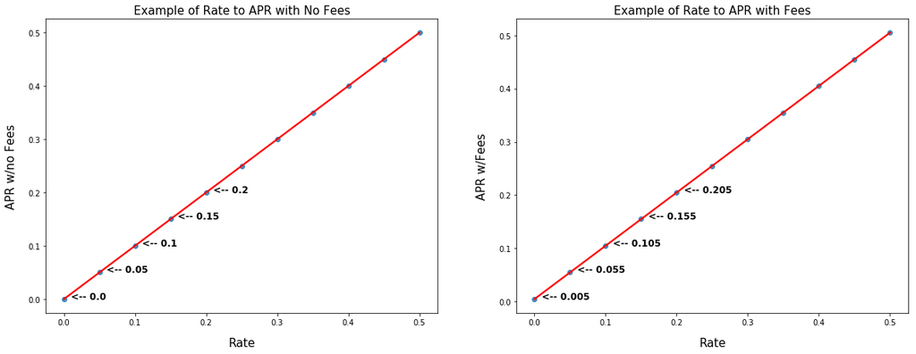

```python
"""Graph a Side by Side Scatterplots in Seaborn"""

# set a larger figure size for subplots (width, height (inches); default 6.4, 4.8)
plt.figure(figsize = [20, 7])

#no regression line in matplotlib
# 1 row, 2 cols, subplot 1
plt.subplot (1, 2, 1)
sb.regplot(data = BankFeesExample, x = 'Rate', y = 'NoFees',
           #scatter_kws = {"color": "g"},
           line_kws = {"color": "red"});

plt.title("Example of Rate to APR with No Fees", fontsize=15)
plt.xlabel("Rate", fontsize=15, labelpad=14)
plt.ylabel("APR w/no Fees", fontsize=15, labelpad=14);

#adds the data point labeling for subplot 1
for row in BankFeesExample.itertuples():
    x = row.Rate
    y = row.NoFees
    if y == 0.25:
        break   #break & exit loop at y = 0.25

    #no arrow
    #str = "({0},{1})".format(x,y)
    #plt.annotate(str, (x ,y), fontsize='large', fontweight='bold')

    #w/arrow
    str = "<-- {0}".format(y)
    plt.annotate(str, (x +0.01 ,y), fontsize='large', fontweight='bold')



#with colored regression line in seaborn
# 1 row, 2 cols, subplot 2
plt.subplot (1, 2, 2)
sb.regplot(data = BankFeesExample, x = 'Rate', y = 'WithFees',
           #scatter_kws = {"color": "g"},
           line_kws = {"color": "red"}

          );
plt.title("Example of Rate to APR with Fees", fontsize=15)
plt.xlabel("Rate", fontsize=15, labelpad=14)
plt.ylabel("APR w/Fees", fontsize=15, labelpad=14);

#adds the data point labeling for subplot 2
for row in BankFeesExample.itertuples():
    x = row.Rate
    y = row.WithFees
    if y == 0.2550:
        break    #break & exit loop at y = 0.2550
    #no arrow
    #str = "({0},{1})".format(x,y)
    #plt.annotate(str, (x ,y), fontsize='large', fontweight='bold')

    #with arrow
    str = "<-- {0}".format(y)
    plt.annotate(str, (x +0.01 ,y), fontsize='large', fontweight='bold')
```

Notice two important points from the previous slide:

First, perfect linearity is shown in both graphs because fees were evenly distributed throughout the range of interst rates.

Second, there was a slight vertical, y-axis (APR) shift (0.005) when fees were applied to any given interest rate.

These two points (perfect linearity & a slight shift) are important to bear in mind as we leave the "perfect world" and enter the "real world" of Prosper Loans.

## Let's compare the "Real World" example of Interest Rate to APR.

We can begin the "real world" examination of Prosper Loans by observing how closely the relationship of BorrowerRate and APR mimic what we described in our previous "perfect world" example:

is complete linearity maintained and is there some level of upshift evident in APR over the interest rate?

First, we'll view the univariate counts of BorrowerRate & BorrowerAPR individually with this graph (APR on the left, Rate on the right):

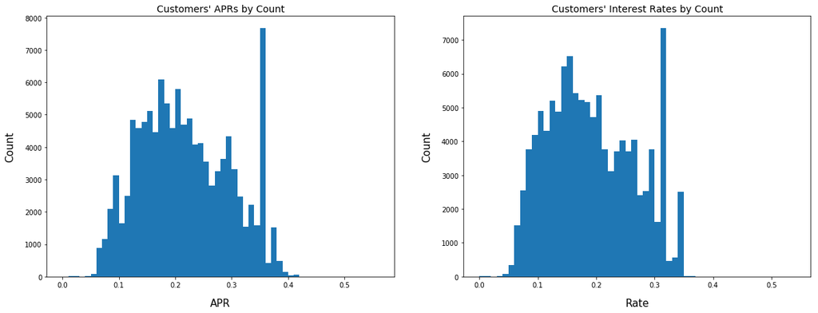

```python
"""Graph Side by Side Histograms in Matplotlib"""

# set a larger figure size for subplots (width, height (inches); default 6.4, 4.8)
plt.figure(figsize = [20, 7])

# 1 row, 2 cols, subplot 1
plt.subplot (1, 2, 1)
bins = np.arange(0, loan_data['BorrowerAPR'].max()+.05, .010)
plt.hist(data = loan_data, x = 'BorrowerAPR', bins = bins);

plt.title("Customers' APRs by Count", fontsize=14)
plt.xlabel("APR", fontsize=15, labelpad=14) #offsets label
plt.ylabel("Count", fontsize=15, labelpad=14); #offsets label


# 1 row, 2 cols, subplot 2
plt.subplot (1, 2, 2)
bins = np.arange(0, loan_data['BorrowerRate'].max()+.05, .010)
plt.hist(data = loan_data, x = 'BorrowerRate', bins = bins);

plt.title("Customers' Interest Rates by Count", fontsize=14)
plt.xlabel("Rate", fontsize=15, labelpad=14) #offsets label
plt.ylabel("Count", fontsize=15, labelpad=14); #offsets label
```

The previous graph shows a slight shift of the bulk of the counts a little further right on the x-axis on the previous slide, but it's difficult to confirm.

A better test to visually compare how closely our real world enviroment mirrors our perfect world enviornment is through a scatterplot which graphs the bivariate relationship between two variables like Rate & APR.

Prior to that however, we'll begin by calculating a correlation coefficient.

A correlation coefficient is number that ranges between -1.0 and 1.0. Its purpose is to show the strength of a relationship between two variables. The option varies from a very strong, negative relationship, through no relationship, to a very strong positive relationship. Here, positive and negative represent nothing more than the direction of the relationship when graphed on an x-y axis.

This indicates a very strong positive relationship of BorrowerRate to BorrowerAPR.

In this case, the correlation coefficient has indicated a very strong positive relationship of BorrowerRate to BorrowerAPR.

The following scatterplot of Rate to APR should comfirm the previous slide's findings. We should look for a very strong, linear positive relationship. The advantage here is that scatterplot will visually describe the linearity as well as the variation:

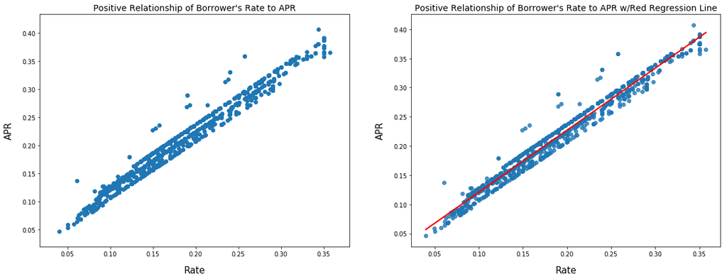

```python
"""Graph Side by Side Scatterplots in Matplotlib"""

loan_data_subset_4 = loan_data.sample(1000, random_state=42, replace=True)

# set a larger figure size for subplots (width, height (inches); default 6.4, 4.8)
plt.figure(figsize = [20, 7])

#no regression line in matplotlib
# 1 row, 2 cols, subplot 1
plt.subplot (1, 2, 1)
plt.scatter(data = loan_data_subset_4, x = 'BorrowerRate', y = 'BorrowerAPR');
plt.title("Positive Relationship of Borrower's Rate to APR", fontsize=14)
plt.xlabel("Rate", fontsize=15, labelpad=14) #offsets label
plt.ylabel("APR", fontsize=15, labelpad=14); #offsets label


#with colored regression line in seaborn
# 1 row, 2 cols, subplot 2
plt.subplot (1, 2, 2)
sb.regplot(data = loan_data_subset_4, x = 'BorrowerRate', y = 'BorrowerAPR',
           #scatter_kws = {"color": "g"},
           line_kws = {"color": "red"});
plt.title("Positive Relationship of Borrower's Rate to APR w/Red Regression Line", fontsize=14)
plt.xlabel("Rate", fontsize=15, labelpad=14) #offsets label
plt.ylabel("APR", fontsize=15, labelpad=14); #offsets label
```

As we interpret the previous slide and focus on the slide on the right in particular, we see the "real world" of Prosper Loans mimicing the "perfect world" example we had shown a few slides previously, at least to a certain point.

First, we have confirmation of a veritical, y-axis (APR) shift. Meaning following the regression line, you can see that APR is approximately 0.02 higher than Rate.

The second point, however, is a little more problematic. There is some level of variation surrounding the regression line. We can think of the regression line here as the same as our perfect world previously; both show where no amount of data variation applies as data points stray from the red regression line.

It's this variation that we'll seek to explain with various third variables. Patterns could emerge when third variables are superimposed on the above graphs than aren't evident when the graphs remain strictly bivariate.

We'll begin this exploration of trying to explain that variation by adding a debt to income ratio as the third variable.

## BorrowerRate, BorrowerAPR & DebtToIncomeRatio

We superimpose a color filter of DebtToIncomeRatio information on top of the existing bivariate, Rate to APR scatterplot and arrive at multivariate plot.

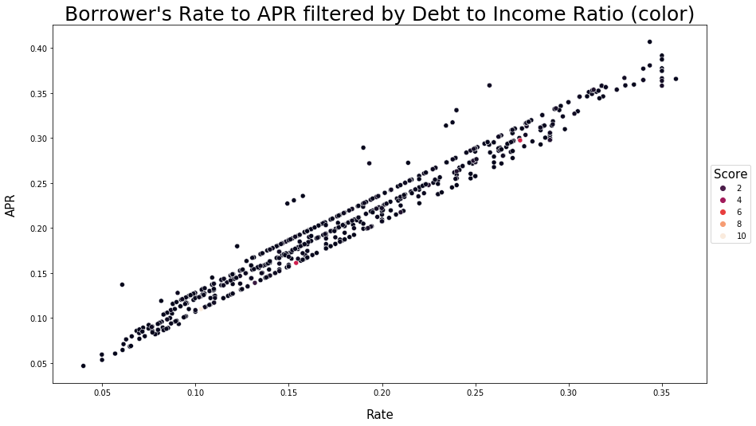

```python
"""Graph a Scatterplot (with 3rd Variable Added) in Seaborn"""

plt.figure(figsize=[14.70, 8.27])
sb.scatterplot(data = loan_data_subset_4,
              x = "BorrowerRate", y = "BorrowerAPR",
              hue = "DebtToIncomeRatio", palette="rocket");

plt.legend(loc='center left', bbox_to_anchor=(1, 0.5),
           title="Score", title_fontsize =15);

plt.title("Borrower's Rate to APR filtered by Debt to Income Ratio (color)", fontsize=25)
plt.xlabel("Rate", fontsize=15, labelpad=15) #offsets label
plt.ylabel("APR", fontsize=15, labelpad=15); #offsets label
```

Unfortunately, the previous slide showing a DebtToIncomeRatio filter doesn't offer any help in explaining the variation that occurs between BorrowerRate to BorrowerAPR. Essentially, it tells us that, save for a couple of stragglers, the majority of Debt to Income ratios are under .20 throughout the relationship of Interest Rate to APR.

We'll add the Prosper Score next.

## BorrowerRate, BorrowerAPR & ProsperScore

Here we'll apply the ProsperScore (a credit score created internally by Prosper Loans) as the third variable in Rate to APR.

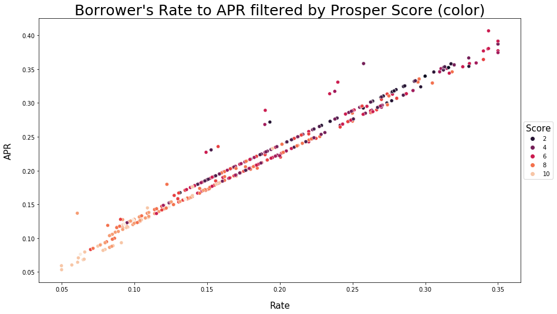

```python
"""Graph a Scatterplot (with 3rd Variable Added) in Seaborn"""

plt.figure(figsize=[14.70, 8.27])
sb.scatterplot(data = loan_data_subset_4,
              x = "BorrowerRate", y = "BorrowerAPR",
              hue = "ProsperScore", palette="rocket");

plt.legend(loc='center left', bbox_to_anchor=(1, 0.5),
           title="Score", title_fontsize =15);

plt.title("Borrower's Rate to APR filtered by Prosper Score (color)", fontsize=25)
plt.xlabel("Rate", fontsize=15, labelpad=15) #offsets label
plt.ylabel("APR", fontsize=15, labelpad=15); #offsets label
```

As seen in the previous slide, when applying the ProsperScore there is some variation evident when viewing the prosper score range of 4-7.

A deeper dive is required to better confirm this:

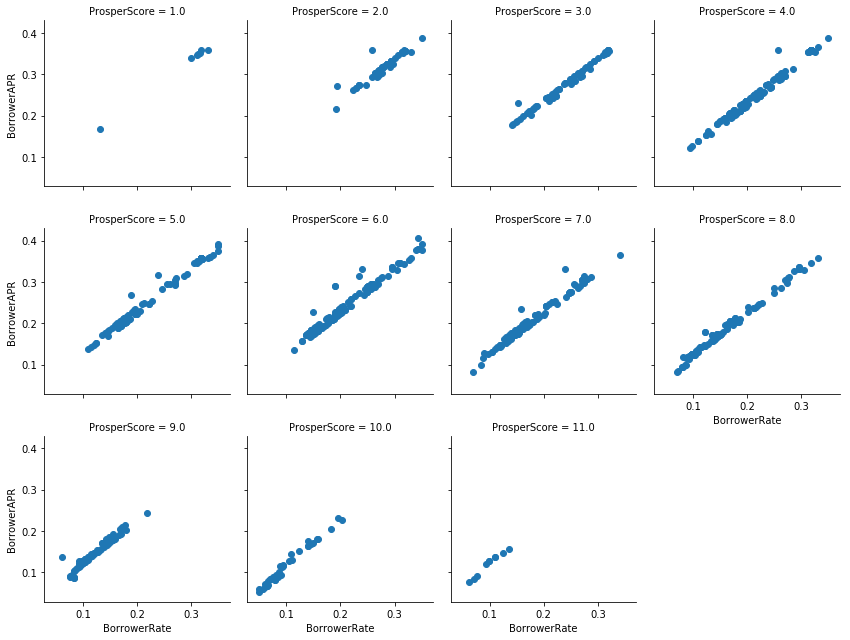

```python
"""Graph Faceted Scatterplots in Seaborn"""

#same data but facetgridded out by ProsperScore

g = sb.FacetGrid(data = loan_data_subset_4, col = 'ProsperScore', col_wrap =4, height =3)
g.map(plt.scatter, 'BorrowerRate', 'BorrowerAPR');
```

When the same data is broken down by individual scores, we can confirm that indeed the most variation of Rate to APR occurs in the 4 to 7 Prosper score range. This is promising.

We'll turn to the loan term next.

### BorrowerRate, BorrowerAPR & Term

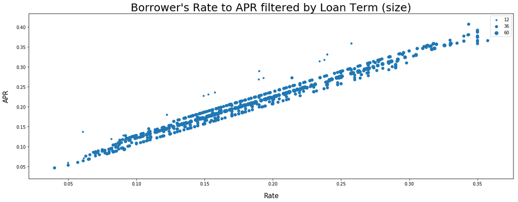

```python
"""Graph a Scatterplot (with 3rd Variable Added) in Matplotlib"""

# set a larger figure size for subplots (width, height (inches); default 6.4, 4.8)
plt.figure(figsize = [20, 7])

plt.scatter(data = loan_data_subset_4, x = 'BorrowerRate', y = 'BorrowerAPR', s = 'Term')

# dummy series for adding legend
sizes = [12, 36, 60]
base_color = sb.color_palette()[0]
legend_obj = []

#plt.figure(figsize=(14, 6))
for s in sizes:
    legend_obj.append(plt.scatter([], [], s = s, color = base_color))

plt.title("Borrower's Rate to APR filtered by Loan Term (size)", fontsize=25)
plt.xlabel("Rate", fontsize=15, labelpad=15) #offsets label
plt.ylabel("APR", fontsize=15, labelpad=15) #offsets label

plt.legend(legend_obj, sizes);
```

The previous graph highlights one of the difficulties of not specifically manipulating the inputs when initially setting up a graph. By using the same large sample and no jittering, the size differentiations (12, 36 & 60 months) are difficult to distingush. We can use a smaller sample size with some jittering or we can break out this graph as well. We'll break out here:

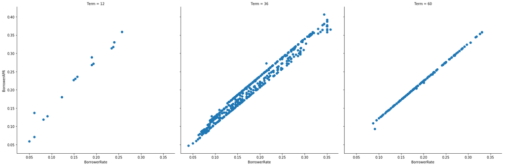

```python
"""Graph Faceted Scatterplots in Seaborn"""

#same data but facetgridded out by loan term

g = sb.FacetGrid(data = loan_data_subset_4, col = 'Term', height =7)
g.map(plt.scatter, 'BorrowerRate', 'BorrowerAPR');
```

By breaking out by term, the previous graphs show almost complete linearity at 60 months and large amounts of variation at 36 months. This is an interesting observation as well.

We'll complete our multivariate analysis with the listing creation date.

### BorrowerRate, BorrowerAPR & ListingCreationDate

The final 3rd variable code we'll investigate in this study is the Listing Creation Datae. Through investigation I determined the median date was 06/1012, within a spread of dates ranging from 11/2005 to 10/2014.

When graphing, we'll also pay attention to dates before and after 2009, as a major financial crisis took place during that period and stricter controls were put place on the banking industry. Perhaps more variation will be shown before 2009 than after 2009?

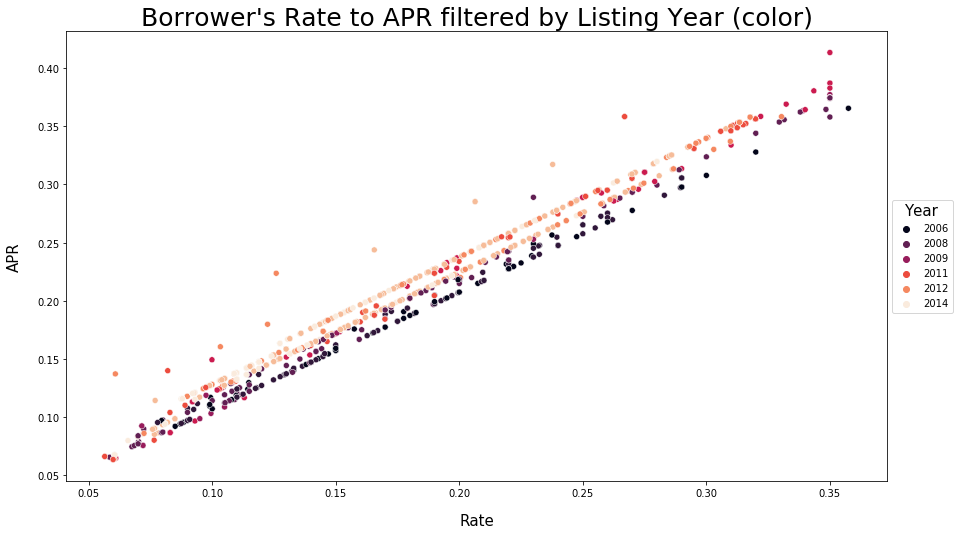

```python
"""Graph a Scatterplot (with 3rd Variable Added) in Seaborn"""

plt.figure(figsize=[14.70, 8.27])
sb.scatterplot(data = loan_data_subset_5,
              x = "BorrowerRate", y = "BorrowerAPR",
              hue = "ListingCreationYear", palette="rocket");

plt.legend(loc='center left', bbox_to_anchor=(1, 0.5),
           title="Year", title_fontsize =15);

plt.title("Borrower's Rate to APR filtered by Listing Year (color)", fontsize=25)
plt.xlabel("Rate", fontsize=15, labelpad=15) #offsets label
plt.ylabel("APR", fontsize=15, labelpad=15); #offsets label
```

If there is more linearity (thereby, less variation) in the previous slide, it appears that it occurs at the begining of the period (2006-2008). We can break this out as well to confirm that appearance.

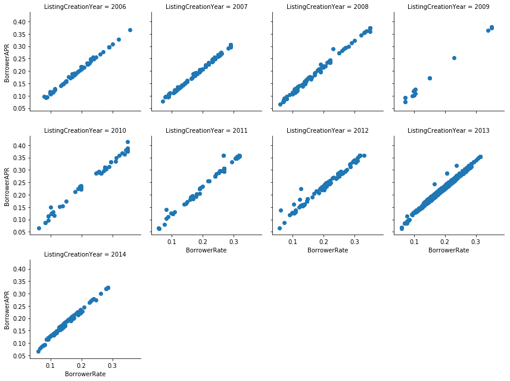

```python
"""Graph Faceted Scatterplots in Seaborn"""

g = sb.FacetGrid(data = loan_data_subset_5, col = 'ListingCreationYear', col_wrap =4, height =3)
g.map(plt.scatter, 'BorrowerRate', 'BorrowerAPR');
```

The interesting thing here is that there is some variation that can be seen when the loan origination date is applied but there isn't a lot and its' confined to the middle of the range of years (2010-2012) rather than before the financial crisis hit (2009). The most linearity does appear to be at the beginning and ending of the range.

### In Conclusion

Though these four variables may not have conclusively shown to be potential causes in the variability that lies between Interest Rate & APR, the analyst still very much in the validity of the question being posed: there must be some reason, or multiple reasons, that causes the variability indicated by the initial Rate to APR scatterplot. Further, understanding the parameter of Interest Rate & APR themselves, there really shouldn't be variability at all; all APR fees should be applied uniformally throughout the range of interest rates.

If we were to continue with this investigation, we have a couple of options. First, we could take some of the 3rd variables that showed promise (Prosper Score & Term, perhaps) and investigate them more deeply. Or, we could apply the same format we used here and begin investigating any one or more of the remaining 77 variables that Prosper Loans makes available to us. Whichever path is chosen, the analyst feels it's worth the effort; the answer is out there.